# Human Activity Recognition: Machine Learning Prediction Model

# 1.2 Prediction Models

We create 3 fit model Decision Tree, Random Forest, Gradient Boostin and then we test the out of sample performance to select the best model for our prediction.

## Decision Tree

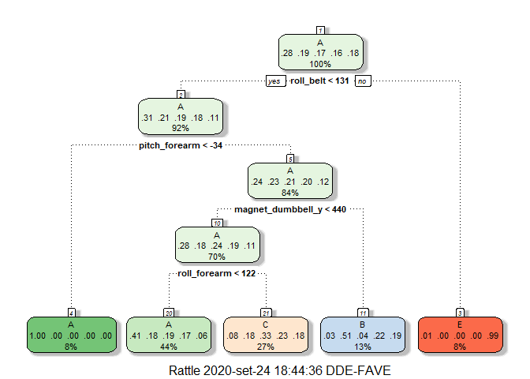

```r
fitDT <- train(classe ~ ., data = training, method= "rpart")
fancyRpartPlot(fitDT$finalModel)
```

## Random Forest

```r
# 3 times cross validation.
my_control <- trainControl(method = "cv", number = 3 )
fitRF <- train(classe ~ ., data = training, method= "rf", prox=TRUE, ntree = 100, trControl=my_control)
```

## Gradient Boosting

```r
my_control <- trainControl(method = "cv", number = 3 )
fitGBM <- train(classe ~ ., data = training, method= "gbm", verbose=FALSE, trControl=my_control )
```

# 1.3 Accuracy Test and Alghoritm Selection

```r
test<-test %>% mutate_at(vars(-classe) ,as.numeric)

predDT <- predict(fitDT, test)
predRF <- predict(fitRF, test)
predGBM <- predict(fitGBM, test)

accuracyDT <-  confusionMatrix(as.factor(test$classe), as.factor(predDT))
accuracyRF <-  confusionMatrix(as.factor(test$classe), as.factor(predRF))
accuracyGBM <- confusionMatrix(as.factor(test$classe), as.factor(predGBM))

kable((rbind( c(ModelFit= "Decision Tree",accuracyDT$overall[1]), c(ModelFit= "Random Forest",accuracyRF$overall[1]), c(ModelFit= "Gradient boosting",accuracyGBM$overall[1]))))
```

| ModelFit | Accuracy |
| --- | --- |
| Decision Tree | 0.495497026338148 |
| Random Forest | 0.993712829226848 |
| Gradient boosting | 0.965845369583687 |

```r
bestFit <- fitRF
```

We select the Random Forest as best fit, because the **accuracy** is of 99.3712829% and the **out of sample error** is 0.6287171% .

# 1.4 Prediction

Now we use the best fit algorithm to predict the classe of the prediction set of the exercise.

```r
prediction_final_dataset<-prediction_final_dataset %>% mutate_at(vars(-problem_id) ,as.numeric)
predict(bestFit, prediction_final_dataset)
```

[1] B A B A A E D B A A B C B A E E A B B B Levels: A B C D E

# 1.5 Conclusion

In this analysis we start from a wide dataset with 160 variables; initially we reduced the variables removing variables with high level on NA values and with near zero variance that can bring bias to out models.

We find that **Random Forest** is the best performing model with an accuracy out of sample of 99.3712829%

We use this model to predict the classes of a new dataset with 20 cases.